# Yale Quan - STAT 595 HW 1 #8

Problem 8:

This exercise relates to the College data set, which can be found in the file College.csv. It contains a number of variables for 777 different universities and colleges in the US.

```r
#Load packages
library("ISLR")
library("GGally")
library("ggplot2")
library("dplyr")
library("scales")
```

1. Use the read.csv() function to read the data into R. Call the loaded data college. Make sure that you have the directory set to the correct location for the data.

```r
# Load the dataset
College_HW = ISLR::College
```

2. Look at the data using the fix() function. You should notice that the first column is just the name of each university. We don’t really want R to treat this as data. However, it may be handy to have these names for later.

```r
fix(College_HW)
```

C_i). Use the summary() function to produce a numerical summary of the variables in the data set.

```r
summary(College_HW)
```

```
 Private        Apps           Accept          Enroll       Top10perc       Top25perc
 No :212   Min.   :   81   Min.   :   72   Min.   :  35   Min.   : 1.00   Min.   :  9.0
 Yes:565   1st Qu.:  776   1st Qu.:  604   1st Qu.: 242   1st Qu.:15.00   1st Qu.: 41.0
           Median : 1558   Median : 1110   Median : 434   Median :23.00   Median : 54.0
           Mean   : 3002   Mean   : 2019   Mean   : 780   Mean   :27.56   Mean   : 55.8
           3rd Qu.: 3624   3rd Qu.: 2424   3rd Qu.: 902   3rd Qu.:35.00   3rd Qu.: 69.0
           Max.   :48094   Max.   :26330   Max.   :6392   Max.   :96.00   Max.   :100.0
  F.Undergrad     P.Undergrad         Outstate       Room.Board       Books           Personal
 Min.   :  139   Min.   :    1.0   Min.   : 2340   Min.   :1780   Min.   :  96.0   Min.   : 250
 1st Qu.:  992   1st Qu.:   95.0   1st Qu.: 7320   1st Qu.:3597   1st Qu.: 470.0   1st Qu.: 850
 Median : 1707   Median :  353.0   Median : 9990   Median :4200   Median : 500.0   Median :1200
 Mean   : 3700   Mean   :  855.3   Mean   :10441   Mean   :4358   Mean   : 549.4   Mean   :1341
 3rd Qu.: 4005   3rd Qu.:  967.0   3rd Qu.:12925   3rd Qu.:5050   3rd Qu.: 600.0   3rd Qu.:1700
 Max.   :31643   Max.   :21836.0   Max.   :21700   Max.   :8124   Max.   :2340.0   Max.   :6800
      PhD            Terminal       S.F.Ratio      perc.alumni        Expend        Grad.Rate
 Min.   :  8.00   Min.   : 24.0   Min.   : 2.50   Min.   : 0.00   Min.   : 3186   Min.   : 10.00
 1st Qu.: 62.00   1st Qu.: 71.0   1st Qu.:11.50   1st Qu.:13.00   1st Qu.: 6751   1st Qu.: 53.00
 Median : 75.00   Median : 82.0   Median :13.60   Median :21.00   Median : 8377   Median : 65.00
 Mean   : 72.66   Mean   : 79.7   Mean   :14.09   Mean   :22.74   Mean   : 9660   Mean   : 65.46
 3rd Qu.: 85.00   3rd Qu.: 92.0   3rd Qu.:16.50   3rd Qu.:31.00   3rd Qu.:10830   3rd Qu.: 78.00
 Max.   :103.00   Max.   :100.0   Max.   :39.80   Max.   :64.00   Max.   :56233   Max.   :118.00
```

C_ii) Use the pairs() function to produce a scatterplot matrix the first ten columns or variables of the data. Recall that you can reference the first ten columns of a matrix A using A[,1:10].

```
data in column(s) 'Private' are not numeric and were ignored
```

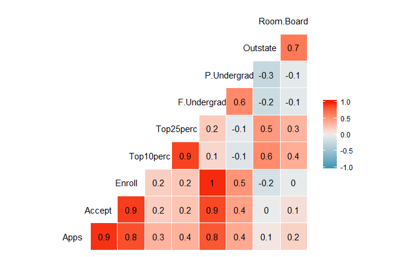

```r
ggcorr(College_HW[,1:10], palette = "RdBu", label = TRUE, hjust = 0.7)
```

C_iii) Use the plot() function to produce side-by-side boxplots of Outstate versus Private.

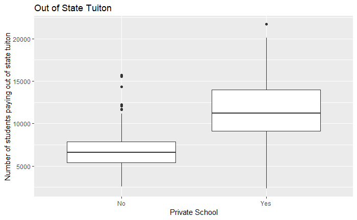

C_iv) Create a new qualitative variable, called Elite, by binning the Top10perc variable. We are going to divide universities into two groups based on whether or not the proportion of students coming from the top 10% of their high school classes exceeds 50%. Use the summary() function to see how many elite universities there are. Now use the plot() function to produce side-by-side boxplots of Outstate versus Elite.

```r
College_HW = mutate(College_HW, Elite = ifelse(College_HW$Top10perc > 50, "Elite", "Not Elite"))
College_HW$Elite = as.factor(College_HW$Elite)
colnames(College_HW)
```

```
 [1] "Private"     "Apps"        "Accept"      "Enroll"      "Top10perc"   "Top25perc"
 [7] "F.Undergrad" "P.Undergrad" "Outstate"    "Room.Board"  "Books"       "Personal"
[13] "PhD"         "Terminal"    "S.F.Ratio"   "perc.alumni" "Expend"      "Grad.Rate"
[19] "Elite"
```

```r
College_HW = College_HW[, c(1, 19, 2, 3, 4, 5, 6, 7, 8, 9, 10, 11, 12, 13, 14, 15, 16, 17, 18)]
head(College_HW)
```

|  | Private | Elite | Apps | Accept | Enroll | Top10perc | Top25perc | F.Undergrad | P.Undergrad | Outstate | Room.Board | Books | Personal | PhD | Terminal | S.F.Ratio | perc.alumni | Expend | Grad.Rate |
| --- | --- | --- | --- | --- | --- | --- | --- | --- | --- | --- | --- | --- | --- | --- | --- | --- | --- | --- | --- |
| 1 | Yes | Not Elite | 1660 | 1232 | 721 | 23 | 52 | 2885 | 537 | 7440 | 3300 | 450 | 2200 | 70 | 78 | 18.1 | 12 | 7041 | 60 |
| 2 | Yes | Not Elite | 2186 | 1924 | 512 | 16 | 29 | 2683 | 1227 | 12280 | 6450 | 750 | 1500 | 29 | 30 | 12.2 | 16 | 10527 | 56 |
| 3 | Yes | Not Elite | 1428 | 1097 | 336 | 22 | 50 | 1036 | 99 | 11250 | 3750 | 400 | 1165 | 53 | 66 | 12.9 | 30 | 8735 | 54 |
| 4 | Yes | Elite | 417 | 349 | 137 | 60 | 89 | 510 | 63 | 12960 | 5450 | 450 | 875 | 92 | 97 | 7.7 | 37 | 19016 | 59 |
| 5 | Yes | Not Elite | 193 | 146 | 55 | 16 | 44 | 249 | 869 | 7560 | 4120 | 800 | 1500 | 76 | 72 | 11.9 | 2 | 10922 | 15 |
| 6 | Yes | Not Elite | 587 | 479 | 158 | 38 | 62 | 678 | 41 | 13500 | 3335 | 500 | 675 | 67 | 73 | 9.4 | 11 | 9727 | 55 |

```r
summary(College_HW)
```

```
 Private         Elite          Apps           Accept          Enroll       Top10perc
 No :212   Elite    : 78   Min.   :   81   Min.   :   72   Min.   :  35   Min.   : 1.00
 Yes:565   Not Elite:699   1st Qu.:  776   1st Qu.:  604   1st Qu.: 242   1st Qu.:15.00
                           Median : 1558   Median : 1110   Median : 434   Median :23.00
                           Mean   : 3002   Mean   : 2019   Mean   : 780   Mean   :27.56
                           3rd Qu.: 3624   3rd Qu.: 2424   3rd Qu.: 902   3rd Qu.:35.00
                           Max.   :48094   Max.   :26330   Max.   :6392   Max.   :96.00
   Top25perc      F.Undergrad     P.Undergrad         Outstate       Room.Board       Books
 Min.   :  9.0   Min.   :  139   Min.   :    1.0   Min.   : 2340   Min.   :1780   Min.   :  96.0
 1st Qu.: 41.0   1st Qu.:  992   1st Qu.:   95.0   1st Qu.: 7320   1st Qu.:3597   1st Qu.: 470.0
 Median : 54.0   Median : 1707   Median :  353.0   Median : 9990   Median :4200   Median : 500.0
 Mean   : 55.8   Mean   : 3700   Mean   :  855.3   Mean   :10441   Mean   :4358   Mean   : 549.4
 3rd Qu.: 69.0   3rd Qu.: 4005   3rd Qu.:  967.0   3rd Qu.:12925   3rd Qu.:5050   3rd Qu.: 600.0
 Max.   :100.0   Max.   :31643   Max.   :21836.0   Max.   :21700   Max.   :8124   Max.   :2340.0
    Personal         PhD            Terminal       S.F.Ratio      perc.alumni        Expend
 Min.   : 250   Min.   :  8.00   Min.   : 24.0   Min.   : 2.50   Min.   : 0.00   Min.   : 3186
 1st Qu.: 850   1st Qu.: 62.00   1st Qu.: 71.0   1st Qu.:11.50   1st Qu.:13.00   1st Qu.: 6751
 Median :1200   Median : 75.00   Median : 82.0   Median :13.60   Median :21.00   Median : 8377
 Mean   :1341   Mean   : 72.66   Mean   : 79.7   Mean   :14.09   Mean   :22.74   Mean   : 9660
 3rd Qu.:1700   3rd Qu.: 85.00   3rd Qu.: 92.0   3rd Qu.:16.50   3rd Qu.:31.00   3rd Qu.:10830
 Max.   :6800   Max.   :103.00   Max.   :100.0   Max.   :39.80   Max.   :64.00   Max.   :56233
   Grad.Rate
 Min.   : 10.00
 1st Qu.: 53.00
 Median : 65.00
 Mean   : 65.46
 3rd Qu.: 78.00
 Max.   :118.00
```

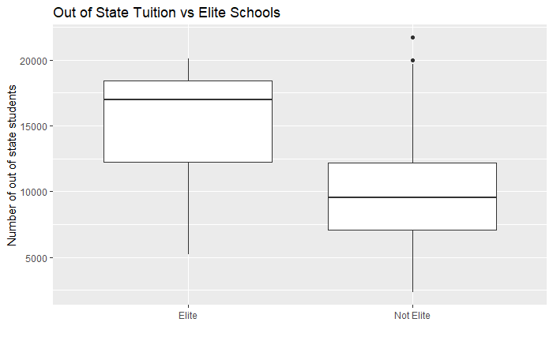

```r
out_vs_elite = ggplot(data = College_HW, aes(Elite, Outstate))
out_vs_elite + geom_boxplot() + ggtitle("Out of State Tuition vs Elite Schools") +  xlab("") + ylab("Number of out of state students")
```

4. Use the hist() function to produce some histograms with differing numbers of bins for a few of the quantitative variables. You may find the command par(mfrow=c(2,2)) useful: it will divide the print window into four regions so that four plots can be made simultaneously. Modifying the arguments to this function will divide the screen in other ways.

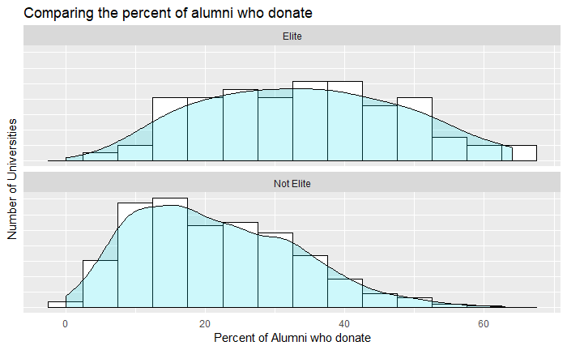

```r
ggplot(data = College_HW, aes(x = perc.alumni)) + geom_histogram(aes(y=..density..), binwidth = 5, color = "black", fill = "white") + geom_density(alpha = 0.2, fill = "#07DEED") + theme(axis.ticks = element_blank(), axis.text.y = element_blank()) + facet_wrap(~Elite, ncol = 1) + ggtitle("Comparing the percent of alumni who donate") + xlab("Percent of Alumni who donate") + ylab("Number of Universities")
```

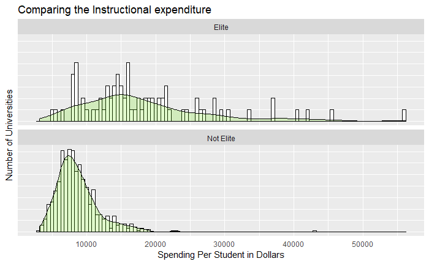

```r
ggplot(data = College_HW, aes(x=Expend)) + geom_histogram(aes(y = ..density..), binwidth = 500, color = "black", fill = "white") + geom_density(alpha = 0.2, fill = "#67ED00") + theme(axis.ticks = element_blank(), axis.text.y = element_blank()) + facet_wrap(~Elite, ncol = 1) + ggtitle("Comparing the Instructional expenditure") + xlab("Spending Per Student in Dollars") + ylab("Number of Universities")
```

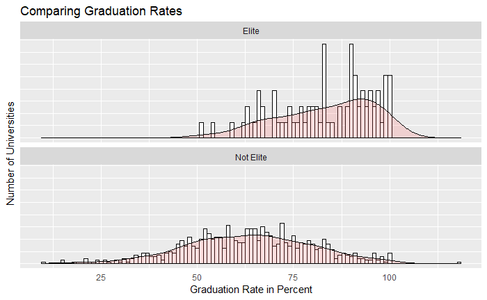

```r
ggplot(data = College_HW, aes(x=Grad.Rate)) + geom_histogram(aes(y=..density..),binwidth = 1, color = "black", fill = "white") + geom_density(alpha = 0.2, fill = "#FF6666") + theme(axis.ticks = element_blank(), axis.text.y = element_blank()) + facet_wrap(~Elite, ncol = 1) + ggtitle("Comparing Graduation Rates") + xlab("Graduation Rate in Percent") + ylab("Number of Universities")
```

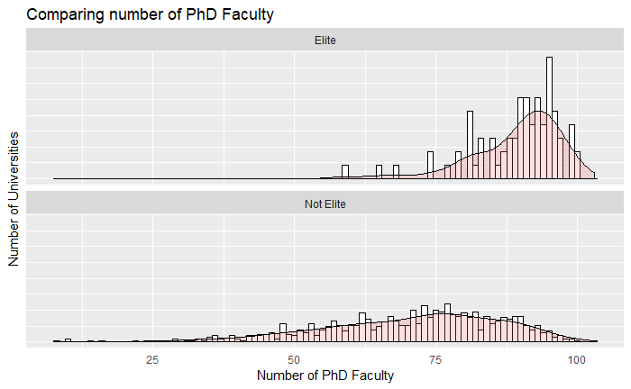

```r
ggplot(data = College_HW, aes(x=PhD)) + geom_histogram(aes(y=..density..),binwidth = 1, color = "black", fill = "white") + geom_density(alpha = 0.2, fill = "#FF6666") + theme(axis.ticks = element_blank(), axis.text.y = element_blank()) + facet_wrap(~Elite, ncol = 1) + ggtitle("Comparing number of PhD Faculty") + xlab("Number of PhD Faculty") + ylab("Number of Universities")
```

```r
College_HW = mutate(College_HW, Rejected = Apps - Accept)
colnames(College_HW)
```

```
 [1] "Private"     "Elite"       "Apps"        "Accept"      "Enroll"      "Top10perc"
 [7] "Top25perc"   "F.Undergrad" "P.Undergrad" "Outstate"    "Room.Board"  "Books"
[13] "Personal"    "PhD"         "Terminal"    "S.F.Ratio"   "perc.alumni" "Expend"
[19] "Grad.Rate"   "Rejected"
```

```r
College_HW = College_HW[, c(1, 2, 3, 4, 5, 20, 6, 7, 8, 9, 10, 11, 12, 13, 14, 15, 16, 17, 18, 19)]
head(College_HW)
```

|  | Private | Elite | Apps | Accept | Enroll | Rejected | Top10perc | Top25perc | F.Undergrad | P.Undergrad | Outstate | Room.Board | Books | Personal | PhD | Terminal | S.F.Ratio | perc.alumni | Expend | Grad.Rate |
| --- | --- | --- | --- | --- | --- | --- | --- | --- | --- | --- | --- | --- | --- | --- | --- | --- | --- | --- | --- | --- |
| 1 | Yes | Not Elite | 1660 | 1232 | 721 | 428 | 23 | 52 | 2885 | 537 | 7440 | 3300 | 450 | 2200 | 70 | 78 | 18.1 | 12 | 7041 | 60 |
| 2 | Yes | Not Elite | 2186 | 1924 | 512 | 262 | 16 | 29 | 2683 | 1227 | 12280 | 6450 | 750 | 1500 | 29 | 30 | 12.2 | 16 | 10527 | 56 |
| 3 | Yes | Not Elite | 1428 | 1097 | 336 | 331 | 22 | 50 | 1036 | 99 | 11250 | 3750 | 400 | 1165 | 53 | 66 | 12.9 | 30 | 8735 | 54 |
| 4 | Yes | Elite | 417 | 349 | 137 | 68 | 60 | 89 | 510 | 63 | 12960 | 5450 | 450 | 875 | 92 | 97 | 7.7 | 37 | 19016 | 59 |
| 5 | Yes | Not Elite | 193 | 146 | 55 | 47 | 16 | 44 | 249 | 869 | 7560 | 4120 | 800 | 1500 | 76 | 72 | 11.9 | 2 | 10922 | 15 |
| 6 | Yes | Not Elite | 587 | 479 | 158 | 108 | 38 | 62 | 678 | 41 | 13500 | 3335 | 500 | 675 | 67 | 73 | 9.4 | 11 | 9727 | 55 |

```r
summary(College_HW)
```

```
 Private         Elite          Apps           Accept          Enroll        Rejected
 No :212   Elite    : 78   Min.   :   81   Min.   :   72   Min.   :  35   Min.   :    0.0
 Yes:565   Not Elite:699   1st Qu.:  776   1st Qu.:  604   1st Qu.: 242   1st Qu.:  131.0
                           Median : 1558   Median : 1110   Median : 434   Median :  326.0
                           Mean   : 3002   Mean   : 2019   Mean   : 780   Mean   :  982.8
                           3rd Qu.: 3624   3rd Qu.: 2424   3rd Qu.: 902   3rd Qu.: 1066.0
                           Max.   :48094   Max.   :26330   Max.   :6392   Max.   :21764.0
   Top10perc       Top25perc      F.Undergrad     P.Undergrad         Outstate       Room.Board
 Min.   : 1.00   Min.   :  9.0   Min.   :  139   Min.   :    1.0   Min.   : 2340   Min.   :1780
 1st Qu.:15.00   1st Qu.: 41.0   1st Qu.:  992   1st Qu.:   95.0   1st Qu.: 7320   1st Qu.:3597
 Median :23.00   Median : 54.0   Median : 1707   Median :  353.0   Median : 9990   Median :4200
 Mean   :27.56   Mean   : 55.8   Mean   : 3700   Mean   :  855.3   Mean   :10441   Mean   :4358
 3rd Qu.:35.00   3rd Qu.: 69.0   3rd Qu.: 4005   3rd Qu.:  967.0   3rd Qu.:12925   3rd Qu.:5050
 Max.   :96.00   Max.   :100.0   Max.   :31643   Max.   :21836.0   Max.   :21700   Max.   :8124
     Books           Personal         PhD            Terminal       S.F.Ratio      perc.alumni
 Min.   :  96.0   Min.   : 250   Min.   :  8.00   Min.   : 24.0   Min.   : 2.50   Min.   : 0.00
 1st Qu.: 470.0   1st Qu.: 850   1st Qu.: 62.00   1st Qu.: 71.0   1st Qu.:11.50   1st Qu.:13.00
 Median : 500.0   Median :1200   Median : 75.00   Median : 82.0   Median :13.60   Median :21.00
 Mean   : 549.4   Mean   :1341   Mean   : 72.66   Mean   : 79.7   Mean   :14.09   Mean   :22.74
 3rd Qu.: 600.0   3rd Qu.:1700   3rd Qu.: 85.00   3rd Qu.: 92.0   3rd Qu.:16.50   3rd Qu.:31.00
 Max.   :2340.0   Max.   :6800   Max.   :103.00   Max.   :100.0   Max.   :39.80   Max.   :64.00
     Expend        Grad.Rate
 Min.   : 3186   Min.   : 10.00
 1st Qu.: 6751   1st Qu.: 53.00
 Median : 8377   Median : 65.00
 Mean   : 9660   Mean   : 65.46
 3rd Qu.:10830   3rd Qu.: 78.00
 Max.   :56233   Max.   :118.00
```

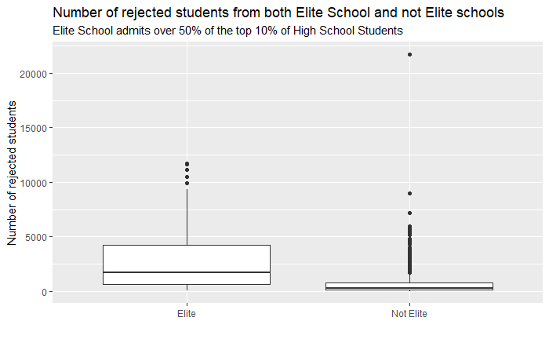

```r
rejected_vs_elite = ggplot(data = College_HW, aes(Elite, Rejected))
apps_vs_elite = ggplot(data = College_HW, aes(x = Elite, y = Apps))
rejected_vs_elite + geom_boxplot() + ggtitle("Number of rejected students from both Elite School and not Elite schools", subtitle = "Elite School admits over 50% of the top 10% of High School Students") +  xlab("") + ylab("Number of rejected students")
```

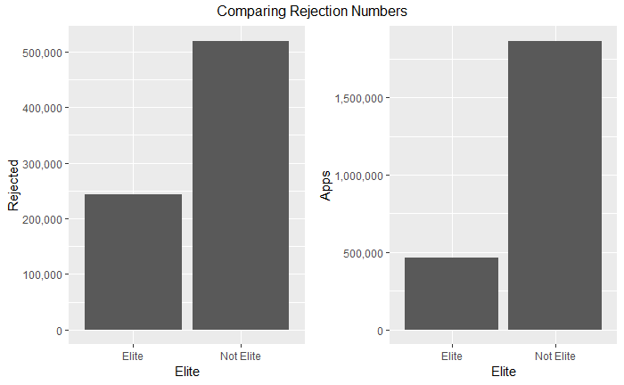

```r
require(gridExtra)
plot1 = rejected_vs_elite + geom_col() + scale_y_continuous(labels = comma)
plot2 = apps_vs_elite + geom_col() + scale_y_continuous(labels = comma)
grid.arrange(plot1, plot2, ncol = 2, top = "Comparing Rejection Numbers")
```

4. Continue exploring the data, and provide a brief summary of what you discover

We can see a strong correlation between many of the variables. There is almost perfect positive linear correlation between Apps and Accept, Accept and Enroll, Apps and Enroll, Enroll and F.Undergrad, Accept and F.Undergrad, Apps and F.Undergrad, and Top10Perc and Top25Perc.

Further data analysis should focus on finding what factors contribute most to a school being considered elite or not.